# Bellabeat R Markdown Analysis

Kevin Folkes

2022-10-29

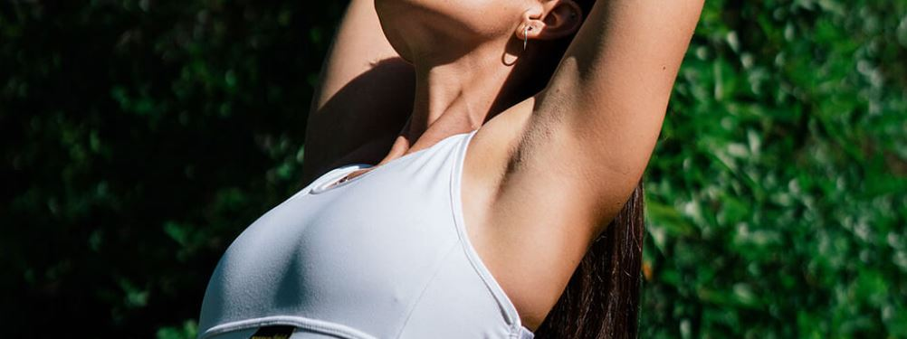

## Introduction

As part of the Google data analytics capstone project, this analysis is on the wellness company for women, [Bellabeat](https://bellabeat.com/) that’s interesting in analyzing smart fitness data that could help unlock new opportunities for the company.

### Stakeholders

- Urška Sršen: Bellabeat’s cofounder and Chief Creative Officer
- Sando Mur: Mathematician and Bellabeat’s cofounder; key member of the Bellabeat executive team.

### Business Task:

Analyze existing smart fitness device usage data and uncover insights and trends that Bellabeat can adopt to positively impact marketing strategy.

### Contraints & ROCCC

Overall the data sets used are not considered reliable:

- The [datasets](https://www.kaggle.com/datasets/arashnic/fitbit) used are from available publicly on Kaggle by the user [Mobius](https://www.kaggle.com/arashnic) and consists of 30 users who consented to the submission of their personal tracker data.
- Users gender are unknown which could lead to a bias or incorrect conclusion.
- Data sets are not current as they were recorded in 2016 and current day user activity may have changed.

### Perpare & Tools

- This analysis was executed using the R programming language with RStudio. Of the available data sets, the ones that were used in this analysis are:
  - dailyActivity_merged
  - sleepDay_merged
- R Packages used:
  - this is a git hub test
  - tidyverse
  - lubridate
  - dplyr
  - ggplot2
  - tidyr
  - rmarkdown
- Github & Rmarkdown will be used to document the full analysis process of the capstone project while Tableau is used for visualizations.

### **Documentation of Cleaning**

#### 1. Installing Packages

```r
# Installing the packages needed for the data analysis

install.packages("tidyverse")
install.packages("lubridate")
install.packages("dplyr")
install.packages("ggplot2")
install.packages("tidyr")
```

#### 1.1 Loading Packages

```r
# Loading the installed libraries

library(tidyverse)
library(lubridate)
```

```r
library(dplyr)
library(ggplot2)
library(tidyr)
```

#### 1.3 Loading Data Sets in R

```r
# Next I will be importing the 2 data sets to be used in the analysis.

dailyActivity <- read.csv("dailyActivity_merged.csv")
sleep <- read.csv("sleepDay_merged.csv")
```

#### 2. Reviwing Data, columns and structure

```r
# Next I will review the data imported to familiarize myself with their headings and data structure

head(dailyActivity)
```

|  | Id | ActivityDate | TotalSteps | TotalDistance | TrackerDistance | LoggedActivitiesDistance | VeryActiveDistance | ModeratelyActiveDistance | LightActiveDistance | SedentaryActiveDistance | VeryActiveMinutes | FairlyActiveMinutes | LightlyActiveMinutes | SedentaryMinutes | Calories |
| --- | --- | --- | --- | --- | --- | --- | --- | --- | --- | --- | --- | --- | --- | --- | --- |
| 1 | 1503960366 | 4/12/2016 | 13162 | 8.50 | 8.50 | 0 | 1.88 | 0.55 | 6.06 | 0 | 25 | 13 | 328 | 728 | 1985 |
| 2 | 1503960366 | 4/13/2016 | 10735 | 6.97 | 6.97 | 0 | 1.57 | 0.69 | 4.71 | 0 | 21 | 19 | 217 | 776 | 1797 |
| 3 | 1503960366 | 4/14/2016 | 10460 | 6.74 | 6.74 | 0 | 2.44 | 0.40 | 3.91 | 0 | 30 | 11 | 181 | 1218 | 1776 |
| 4 | 1503960366 | 4/15/2016 | 9762 | 6.28 | 6.28 | 0 | 2.14 | 1.26 | 2.83 | 0 | 29 | 34 | 209 | 726 | 1745 |
| 5 | 1503960366 | 4/16/2016 | 12669 | 8.16 | 8.16 | 0 | 2.71 | 0.41 | 5.04 | 0 | 36 | 10 | 221 | 773 | 1863 |
| 6 | 1503960366 | 4/17/2016 | 9705 | 6.48 | 6.48 | 0 | 3.19 | 0.78 | 2.51 | 0 | 38 | 20 | 164 | 539 | 1728 |

```r
colnames(dailyActivity)
```

```
##  [1] "Id"                       "ActivityDate"
##  [3] "TotalSteps"               "TotalDistance"
##  [5] "TrackerDistance"          "LoggedActivitiesDistance"
##  [7] "VeryActiveDistance"       "ModeratelyActiveDistance"
##  [9] "LightActiveDistance"      "SedentaryActiveDistance"
## [11] "VeryActiveMinutes"        "FairlyActiveMinutes"
## [13] "LightlyActiveMinutes"     "SedentaryMinutes"
## [15] "Calories"
```

```r
str(dailyActivity)
```

```
## 'data.frame':    940 obs. of  15 variables:
##  $ Id                      : num  1.5e+09 1.5e+09 1.5e+09 1.5e+09 1.5e+09 ...
##  $ ActivityDate            : chr  "4/12/2016" "4/13/2016" "4/14/2016" "4/15/2016" ...
##  $ TotalSteps              : int  13162 10735 10460 9762 12669 9705 13019 15506 10544 9819 ...
##  $ TotalDistance           : num  8.5 6.97 6.74 6.28 8.16 ...
##  $ TrackerDistance         : num  8.5 6.97 6.74 6.28 8.16 ...
##  $ LoggedActivitiesDistance: num  0 0 0 0 0 0 0 0 0 0 ...
##  $ VeryActiveDistance      : num  1.88 1.57 2.44 2.14 2.71 ...
##  $ ModeratelyActiveDistance: num  0.55 0.69 0.4 1.26 0.41 ...
##  $ LightActiveDistance     : num  6.06 4.71 3.91 2.83 5.04 ...
##  $ SedentaryActiveDistance : num  0 0 0 0 0 0 0 0 0 0 ...
##  $ VeryActiveMinutes       : int  25 21 30 29 36 38 42 50 28 19 ...
##  $ FairlyActiveMinutes     : int  13 19 11 34 10 20 16 31 12 8 ...
##  $ LightlyActiveMinutes    : int  328 217 181 209 221 164 233 264 205 211 ...
##  $ SedentaryMinutes        : int  728 776 1218 726 773 539 1149 775 818 838 ...
##  $ Calories                : int  1985 1797 1776 1745 1863 1728 1921 2035 1786 1775 ...
```

```r
# Findings: Date column in the dailyActivity df is set to char
```

#### 3. Data Cleaning - Duplicates

```r
#Checking for duplicates

any(duplicated(dailyActivity))
```

```
## [1] FALSE
```

```r
any(duplicated(sleep))
```

```
## [1] TRUE
```

#### 3.1 Identifying duplicated rowns

```r
which(duplicated(sleep))
```

```
## [1] 162 224 381
```

```r
#Finding: there are duplicated rows in the sleep data set, rows 162, 224, & 381
```

#### 3.2 Modifying date columns

```r
# Cleaning Dates in both data sets

dailyActivity$ActivityDate <- as.Date(dailyActivity$ActivityDate, format = "%m/%d/%Y")
sleep$SleepDay <- as.Date(sleep$SleepDay, format = "%m/%d/%Y")
```

#### 3.3 Removing duplicated roms

```r
# Removing dupilcates from sleep data set

clean_Sleep <- sleep[!duplicated(sleep), ]
str(clean_Sleep)
```

```
## 'data.frame':    410 obs. of  5 variables:
##  $ Id                : num  1.5e+09 1.5e+09 1.5e+09 1.5e+09 1.5e+09 ...
##  $ SleepDay          : Date, format: "2016-04-12" "2016-04-13" ...
##  $ TotalSleepRecords : int  1 2 1 2 1 1 1 1 1 1 ...
##  $ TotalMinutesAsleep: int  327 384 412 340 700 304 360 325 361 430 ...
##  $ TotalTimeInBed    : int  346 407 442 367 712 320 377 364 384 449 ...
```

```r
# 3 rows were removed from data set, observation count went from 413 to 410
```

#### 4. Identifying NA or Null Values.

```r
# Checking for NA or Null values in the data sets

sum(is.na(dailyActivity))
```

```
## [1] 0
```

```r
sum(is.null(dailyActivity))
```

```
## [1] 0
```

```r
sum(is.na(clean_Sleep))
```

```
## [1] 0
```

```r
sum(is.null(clean_Sleep))
```

```
## [1] 0
```

```r
# There are no NA or NUll values in the data sets
```

### **Analyze**

#### 1. Summary of data.

```r
# Summary of both data sets

summary(dailyActivity)
```

```
##        Id             ActivityDate          TotalSteps    TotalDistance
##  Min.   :1.504e+09   Min.   :2016-04-12   Min.   :    0   Min.   : 0.000
##  1st Qu.:2.320e+09   1st Qu.:2016-04-19   1st Qu.: 3790   1st Qu.: 2.620
##  Median :4.445e+09   Median :2016-04-26   Median : 7406   Median : 5.245
##  Mean   :4.855e+09   Mean   :2016-04-26   Mean   : 7638   Mean   : 5.490
##  3rd Qu.:6.962e+09   3rd Qu.:2016-05-04   3rd Qu.:10727   3rd Qu.: 7.713
##  Max.   :8.878e+09   Max.   :2016-05-12   Max.   :36019   Max.   :28.030
##  TrackerDistance  LoggedActivitiesDistance VeryActiveDistance
##  Min.   : 0.000   Min.   :0.0000           Min.   : 0.000
##  1st Qu.: 2.620   1st Qu.:0.0000           1st Qu.: 0.000
##  Median : 5.245   Median :0.0000           Median : 0.210
##  Mean   : 5.475   Mean   :0.1082           Mean   : 1.503
##  3rd Qu.: 7.710   3rd Qu.:0.0000           3rd Qu.: 2.053
##  Max.   :28.030   Max.   :4.9421           Max.   :21.920
##  ModeratelyActiveDistance LightActiveDistance SedentaryActiveDistance
##  Min.   :0.0000           Min.   : 0.000      Min.   :0.000000
##  1st Qu.:0.0000           1st Qu.: 1.945      1st Qu.:0.000000
##  Median :0.2400           Median : 3.365      Median :0.000000
##  Mean   :0.5675           Mean   : 3.341      Mean   :0.001606
##  3rd Qu.:0.8000           3rd Qu.: 4.782      3rd Qu.:0.000000
##  Max.   :6.4800           Max.   :10.710      Max.   :0.110000
##  VeryActiveMinutes FairlyActiveMinutes LightlyActiveMinutes SedentaryMinutes
##  Min.   :  0.00    Min.   :  0.00      Min.   :  0.0        Min.   :   0.0
##  1st Qu.:  0.00    1st Qu.:  0.00      1st Qu.:127.0        1st Qu.: 729.8
##  Median :  4.00    Median :  6.00      Median :199.0        Median :1057.5
##  Mean   : 21.16    Mean   : 13.56      Mean   :192.8        Mean   : 991.2
##  3rd Qu.: 32.00    3rd Qu.: 19.00      3rd Qu.:264.0        3rd Qu.:1229.5
##  Max.   :210.00    Max.   :143.00      Max.   :518.0        Max.   :1440.0
##     Calories
##  Min.   :   0
##  1st Qu.:1828
##  Median :2134
##  Mean   :2304
##  3rd Qu.:2793
##  Max.   :4900
```

```r
summary(clean_Sleep)
```

```
##        Id               SleepDay          TotalSleepRecords TotalMinutesAsleep
##  Min.   :1.504e+09   Min.   :2016-04-12   Min.   :1.00      Min.   : 58.0
##  1st Qu.:3.977e+09   1st Qu.:2016-04-19   1st Qu.:1.00      1st Qu.:361.0
##  Median :4.703e+09   Median :2016-04-27   Median :1.00      Median :432.5
##  Mean   :4.995e+09   Mean   :2016-04-26   Mean   :1.12      Mean   :419.2
##  3rd Qu.:6.962e+09   3rd Qu.:2016-05-04   3rd Qu.:1.00      3rd Qu.:490.0
##  Max.   :8.792e+09   Max.   :2016-05-12   Max.   :3.00      Max.   :796.0
##  TotalTimeInBed
##  Min.   : 61.0
##  1st Qu.:403.8
##  Median :463.0
##  Mean   :458.5
##  3rd Qu.:526.0
##  Max.   :961.0
```

#### 2. User Activity Bar Chart.

```r
# User Activity bar Chart
# calculating the percentage of each activity

Total_Activity_Minutes <- sum(dailyActivity$SedentaryMinutes) +
  sum(dailyActivity$LightlyActiveMinutes) +
  sum(dailyActivity$FairlyActiveMinutes) +
  sum(dailyActivity$VeryActiveMinutes)

Activity_Percent <- data.frame(
  Sedentary = sum(dailyActivity$SedentaryMinutes)/sum (Total_Activity_Minutes) * 100,
  LightlyActive = sum(dailyActivity$LightlyActiveMinutes)/sum (Total_Activity_Minutes) * 100,
  FairlyActive = sum(dailyActivity$FairlyActiveMinutes)/sum (Total_Activity_Minutes) * 100,
  VeryActive = sum(dailyActivity$VeryActiveMinutes)/sum (Total_Activity_Minutes) * 100
)
# Result:  Sedentary LightlyActive FairlyActive VeryActive
# 1  81.32989      15.82049     1.113014   1.736602
```

```r
# creating vectors from the reuslts
Activity_Type <- c("Sedentary", "Lightly_Active", "Fairly_Active", "Very_Active")
Activity_Type_percentage <- c(81.32, 15.82, 1.11, 1.72)
```

```r
# Creating a data frame
Activity_Type_Data <- data.frame(
  Activity_Type, Activity_Type_percentage
)
```

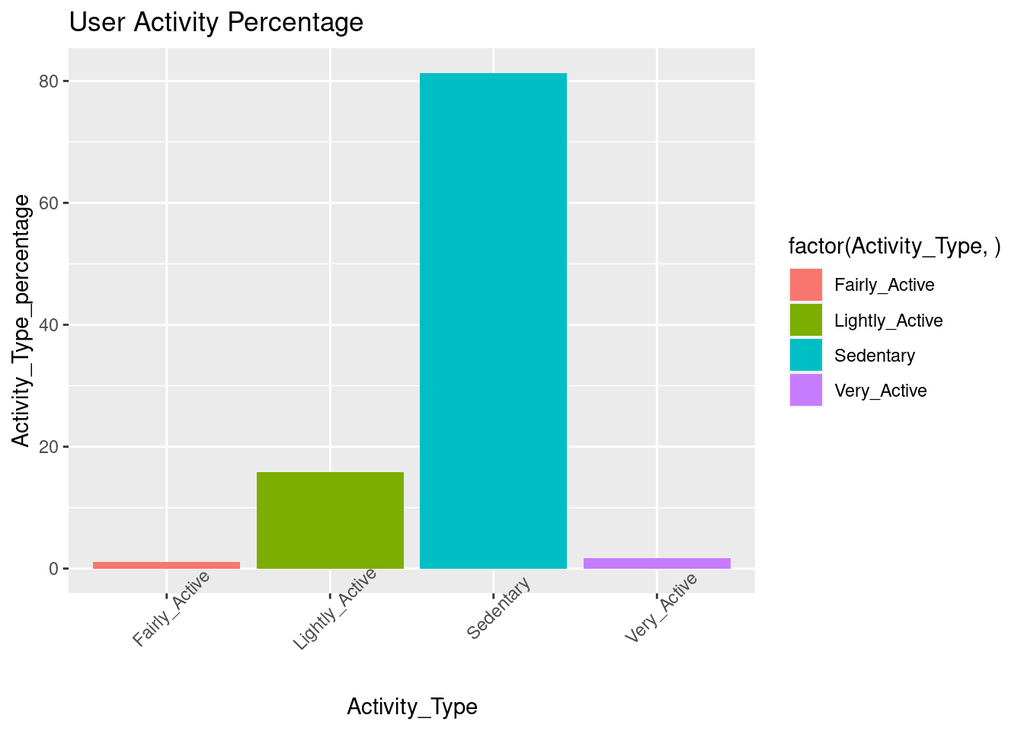

```r
# Creating Activity Bar chart

Activity_Bar_Chart <- ggplot(
  Activity_Type_Data, aes(x = Activity_Type, y = Activity_Type_percentage, fill = factor(Activity_Type,))) + geom_bar(stat = 'identity') + theme(axis.text.x = element_text(angle = 45)) + labs(
    title = "User Activity Percentage"
  )

Activity_Bar_Chart
```

Here we can see that users spent most of their time in a Sedentary state (not active), and when they are in an active state, the activity state is mostly limited to lightly Active rather than fairly active and very active

#### 3. Stacked Bar Chart by Day of the Week.

```r
Day_Week1 <- dailyActivity
Day_Week1$ActivityDate <- weekdays(Day_Week1$ActivityDate)
```

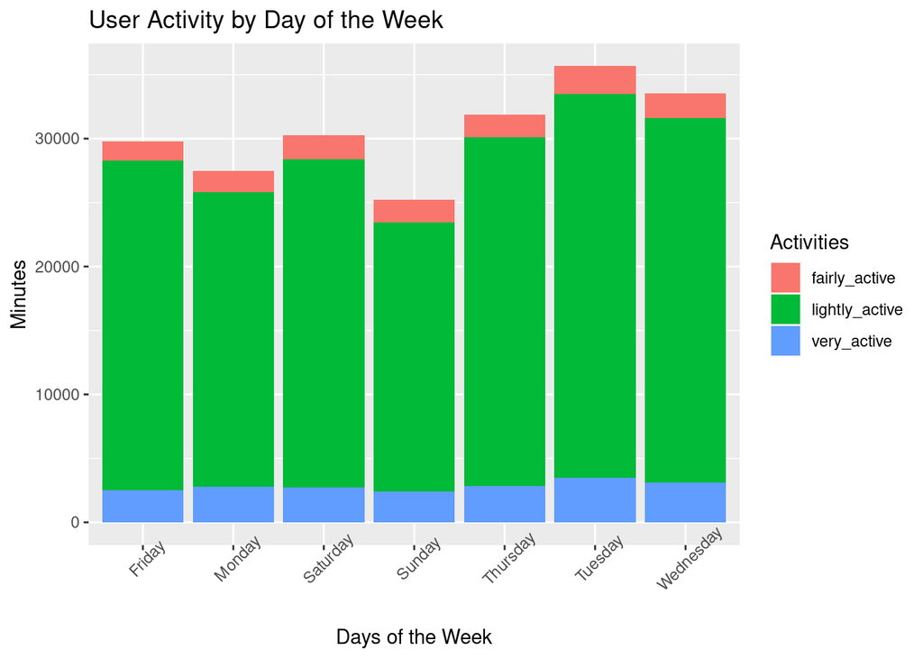

```r
# Activity by day of the week (Very Active, Fairly Active & Lightly Active)
Day_Week1 <- dailyActivity
Day_Week1$ActivityDate <- weekdays(Day_Week1$ActivityDate)

Activity_chart <- Day_Week1 %>%
  group_by(ActivityDate) %>%
  summarize(lightly_active = sum(LightlyActiveMinutes), fairly_active = sum(FairlyActiveMinutes), very_active = sum(VeryActiveMinutes)) %>%
  pivot_longer(-ActivityDate, names_to = "Activities") %>%
  ggplot(aes(ActivityDate, value, fill = Activities)) +
  geom_col() +
  theme(axis.text.x = element_text(angle = 45)) +
  labs(title = "User Activity by Day of the Week",
       y = "Minutes",
       x = "Days of the Week")

Activity_chart
```

Tuesdays was the most active day within the week with Sundays and Mondays being the least active.

#### 4. Correlation Between Steps and Calories.

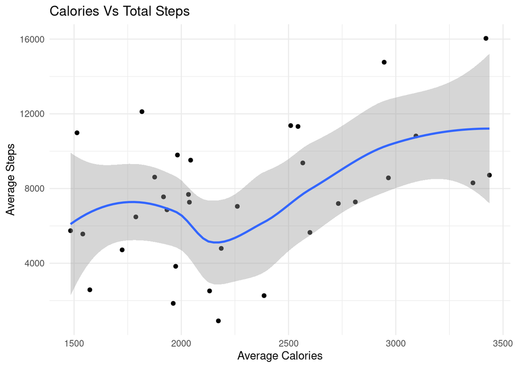

```r
# correlation between total average total steps and the average calories lost.

library(ggplot2)

average_activity <- dailyActivity

average_activity %>%
  group_by (Id) %>%
  summarise(mean_calories = mean(Calories), mean_total_steps = mean(TotalSteps)) %>%
  ggplot(average_activity, mapping = (aes(mean_calories, mean_total_steps))) +
  geom_point(stat = "summary",
             fun = "mean") + geom_smooth() +
  theme_minimal() +
  labs(
    title = "Calories Vs Total Steps",
    x = "Average Calories",
    y= "Average Steps")
```

The correlation between the average steps taken and the average calories lost shows a positive relatiionship, where the more steps you take, the more calories you burn.

#### 5. Correlation Very Active Minutes and Calories.

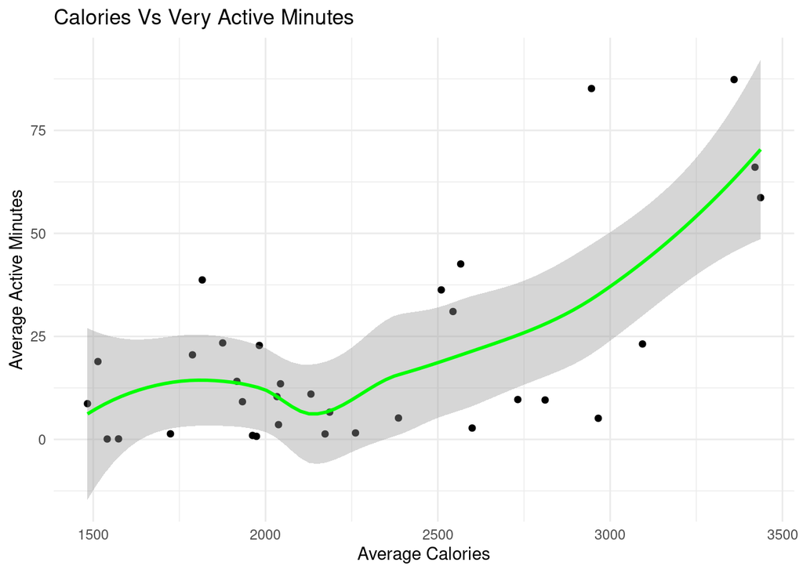

```r
# Correlation between calories vs active minutes
calories_v_activity <- dailyActivity

  calories_v_activity %>%
  group_by (Id) %>%
  summarise(mean_calories = mean(Calories), mean_very_active = mean(VeryActiveMinutes)) %>%
  ggplot(calories_v_activity, mapping = (aes(mean_calories, mean_very_active))) +
  geom_point(stat = "summary",
             fun = "mean") + geom_smooth(color = "green") +
  theme_minimal() +
  labs(
    title = "Calories Vs Very Active Minutes",
    x = "Average Calories",
    y= "Average Active Minutes")
```

The relationship between the average active minutes and the average calories lost is even more positive leading to conclude that the more active your are, the more calories you will lose.

#### 6. Correlation Fairly Active Minutes and Calories.

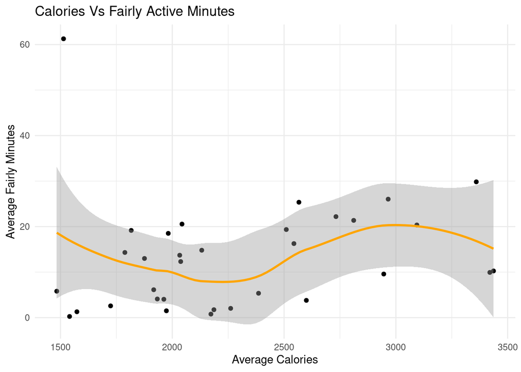

```r
 # Correlation between calories vs fairly minutes

  calories_f_activity <- dailyActivity

  calories_f_activity %>%
    group_by (Id) %>%
    summarise(mean_calories = mean(Calories), mean_fairly_active = mean(FairlyActiveMinutes)) %>%
    ggplot(calories_f_activity, mapping = (aes(mean_calories, mean_fairly_active))) +
    geom_point(stat = "summary",
               fun = "mean") + geom_smooth(color = "orange") +
    theme_minimal() +
    labs(
      title = "Calories Vs Fairly Active Minutes",
      x = "Average Calories",
      y= "Average Fairly Minutes")
```

As the intensity and duration of the activity drops, so does the amount of calories lost. We can see this in the relationship between the average calories and the average of fairly active minutes.

#### 7. Correlation Lightly Active Minutes and Calories.

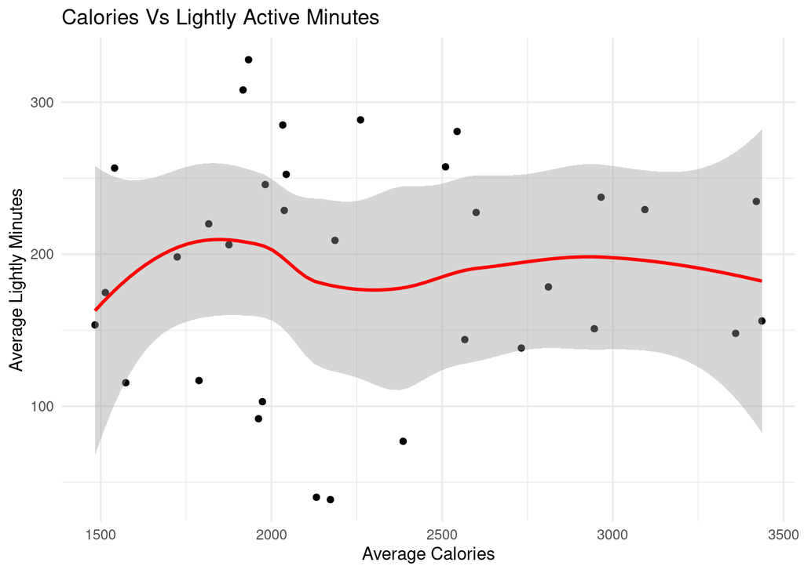

```r
# Correlation between calories vs lightly minutes

  calories_l_activity <- dailyActivity

  calories_l_activity %>%
    group_by (Id) %>%
    summarise(mean_calories = mean(Calories), mean_lightly_active = mean(LightlyActiveMinutes)) %>%
    ggplot(calories_l_activity, mapping = (aes(mean_calories, mean_lightly_active))) +
    geom_point(stat = "summary",
               fun = "mean") + geom_smooth(color = "red") +
    theme_minimal() +
    labs(
      title = "Calories Vs Lightly Active Minutes",
      x = "Average Calories",
      y= "Average Lightly Minutes")
```

The relationship is no longer positive when it comes to lightly active minutes and the average calories lost.

#### 8. Correlation Sleep and Calories.

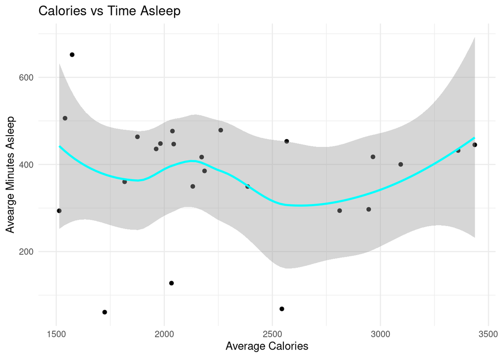

```r
# Correlation between calories and sleep

  AVG_time_wasted_in_bed <- inner_join(dailyActivity, clean_Sleep, by = "Id")

  AVG_time_wasted_in_bed %>%
    group_by(Id) %>%
    summarise(mean_calories = mean(Calories), mean_min_asleep = mean(TotalMinutesAsleep)) %>%
    ggplot(AVG_time_wasted_in_bed, mapping = (aes(mean_calories, mean_min_asleep))) +
    geom_point(
      stat = "summary",
      fun = "mean") + geom_smooth(color = "cyan") +
    labs(
      title = "Calories vs Time Asleep",
      x = "Average Calories",
      y = "Avearge Minutes Asleep"
    ) + theme_minimal()
```

There is no relationship between the average mins spent sleeping and the average amount of calories lost.

#### 9. Clustered Bar Chart Showing Sleep Activities by the Days of the Week.

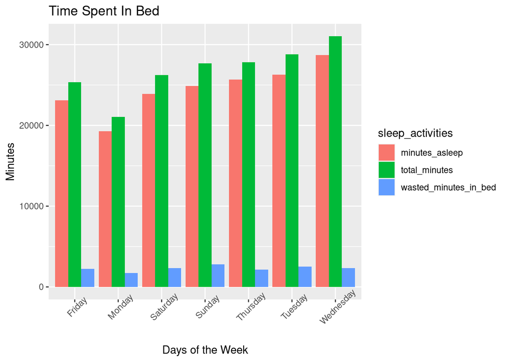

```r
# Grouped bar chart showing time spent in bed activities by days of the week.

  time_wasted_bar_chart <- as.data.frame(clean_Sleep)
  time_wasted_bar_chart$SleepDay <- weekdays(time_wasted_bar_chart$SleepDay)

  dodge_chart <- time_wasted_bar_chart %>%
    group_by(SleepDay) %>%
    summarise(total_minutes = sum(TotalTimeInBed), minutes_asleep = sum(TotalMinutesAsleep), wasted_minutes_in_bed = sum(TotalTimeInBed) - sum(TotalMinutesAsleep)) %>%
    pivot_longer(-SleepDay, names_to = "sleep_activities")

    ggplot(dodge_chart, aes(fill = sleep_activities, x = SleepDay, y = value)) +
      geom_bar(position = "dodge", stat = "identity") +
      theme(axis.text.x = element_text(angle = 45)) +
      labs(
        title = "Time Spent In Bed",
        x = "Days of the Week",
        y = "Minutes"
      )
```

This graphs shows that on Tuesdays and Wednesdays are the days where the most time is spent in bed sleeping however as we learned the in the user activity by day, these were also the days when users spent the most time being active with Monday being the day with the least amount of sleep.

## Recommendations

- Inspire users to be more active by allowing them to create their own personalized goals tailored to their preferred activity type.
- Have the Bellabeat app send notifications when an activity is due and also congratulate when completed to encourage consistency and habit building.
- Have and option for the Bellabeat app to include users sleep cycle and recommend a bed time, sending reminders so users can get adequate rest a d not be distracted while in bed.
- Include a reward system for consistent users (points which can be traded in for a percentage off Bellabeat products and services, gift cards etc…)
- For users that are not active, offer targeted promotions on Sundays & Mondays (least active days).

### Credits & Thank you’s

- *Data used for analysis:* https://www.kaggle.com/datasets/arashnic/fitbit
- *Github*: https://github.com/Jessiah13/Bellabeat_Capstone
- *Tableau:* https://public.tableau.com/app/profile/kevin.folkes8398/viz/BellabeatAnalysis_16657461671170/GoogleDataAnalyticsCapstoneAnalysisBellabeat

*Thank-You!*